# Capstone in Human Cognitive Neuroscience

Michelle R. Greene

Fall 2020

**Instructor**: Michelle R. Greene, Ph.D

**Email**: mgreene2@bates.edu

**Office hours**: [Link](https://calendly.com/mgreenebates/15min) to book me for 15-minute one-on-one in Zoom or in the socially-distanced and masked outdoors.

**Logistics**:

This class is tentatively face to face.

**Prerequisites**: NS/PY 330 and BIO 244, NRSC 205, or PSYC 218

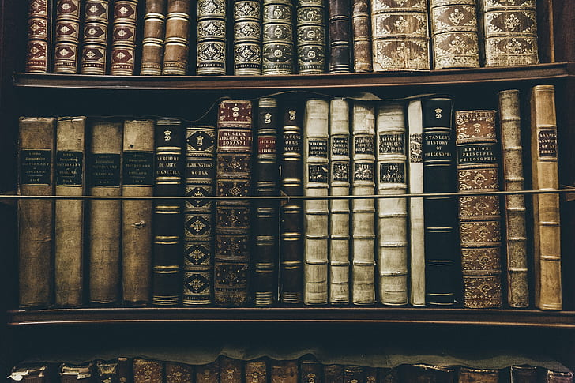

# Purpose

The Capstone Seminar is a culminating experience in your neuroscience or psychology major. This course will provide you the opportunity to flex all of the knowledge and skills that you have gained in your previous courses. Doing research is exhilarating: it requires that you think both inductively and deductively, and above all, with *creativity*. This course will provide you with technical skills in advanced data analysis and computing, in producing technical writing that is clear and engaging, and with soft skills in professional development such as organization and project management.

# Introduction

*“It’s the questions we can’t answer that teach us the most. They teach us how to think. If you give a man an answer, all he gains is a little fact. But give him a question, and he’ll look for his own answers. That way, when he finds the answer it will be precious to him. The harder the question, the harder we hunt. The harder we hunt, the more we learn.”*

Patrick Rothfus, *A Wise Man’s Fear*

As you reach the end of your college career, you find yourself at a critical juncture of your intellectual development. Until this point, you have played the role of student, a passive knowledge receptacle. This course is designed to help you make the leap from knowledge collector to knowledge generator through exploration of topics in at the frontiers of cognitive neuroscience.

At the core, this is a course in how to think about science as a professional scientist does. Together, we will collaboratively learn to ask questions, design and execute on analysis plans, make predictions, take risks, fail, revise, fail again, and iterate until we get it right. Science is a creative enterprise. To create an elegant scientific experiment is to create within a structure, not unlike writing a sonnet or a 12-bar blues. You will be developing your capacity to generate experimental ideas through deliberate practice.

Science is a human enterprise. We will also devote time in this course to discussing our identities as scientists, and the social landscape of science. We will discuss how these both enhance and hinder the quality of scientific work being produced.

In a normal semester, you would be in my lab collecting some of your own data. Unfortunately, all data collection is currently halted due to the Covid-19 pandemic. However, I spent my summer months finding some truly amazing [open databases](https://mrgreene09.github.io/eeg_databases/) that we may work with. This will enable you not only to learn the nuts and bolts of cutting-edge neuroimaging analysis, but to analyze full datasets that in many cases are much larger than what we could collect or are from populations of people we would not have access to.

# Learning Objectives:

- Be able to explain modern methods of EEG analysis at the conceptual level, including multivariate classification (decoding), functional connectivity, regression analysis, and time-frequency analysis.
- Be able to provide some of the strengths and limitations of each of the types of EEG analysis techniques, and be able to identify which EEG analysis techniques are most appropriate for a particular scientific question.
- Be able to critique primary research articles for their merits, contributions, and limitations.
- Devise one or more hypotheses about a given scientific problem, and predict the data patterns that would provide evidence against each hypothesis.
- Visualize scientific results in an accurate, clear, and aesthetically pleasing way.
- Use effective written communication to articulate your scientific question and its significance, fully and accurately describe methods and results, and analyze the results in a way that links the current project to a broader literature in cognitive neuroscience.
- Develop a strategic plan for managing all aspects of your thesis project, and use it to track your progress and manage your time.

# Grading:

I am employing [contract grading](https://writingcommons.org/article/so-your-instructor-is-using-contract-grading/) for this course. This is particularly effective in writing courses because it allows you to focus on progress over perfection, and leads to less subjective grading overall.

Both scientific research and scientific writing are *process-driven*, meaning that they take a lot of practice. Contract-based grading enables us to focus on deliberate practice. Specifically, each required component will be graded on a binary scale: Accept or Revise. When you earn Accept status, this component has met my standard. You will earn Revise if the component does not *yet* earn Accept status. You will then have the opportunity to revise as many times as needed to get to Accept.

**Contract to earn a C:**

- You will turn in something for each of the eight required components for the class.

**Note**: Fractional grades (e.g. B+, A-, etc. are possible).

# Course Components:

### Required Components:

**Ethics Training:** Obtain formal research ethics training and certification through [CITI or NIH](https://www.bates.edu/institutional-review-board/training-requirements-for-human-subjects-researchers/). Although you will not need to submit an IRB proposal for the work that you are doing, it is still important to understand how we protect the rights of the volunteers who take part in these studies.

**Strategic Plan:** The majority of research work is self directed. This means that there is always a temptation to put off working on your thesis because of a more urgent deadline. By planning out this project in detail in advance, you will always have a clear sense of what needs to be done each day to stay on track. In the short run, this will make your thesis a much more pleasant and stress-free process. In the long run, applying the principles of project management to your professional and personal life will make you a much more effective human. You will be paired with an “accountability buddy” to meet weekly to assess what is going well in your plan, and how you might deal with any setbacks that occur.

**Thesis Document:** A PDF document that contains the following sub-components:

- Abstract
- Introduction
- Materials and Methods
- Results
- Discussion
- Reference list

### Supporting Activities:

**[Daily Reading Journal:](https://docs.google.com/document/d/1XLIbw37HbWIZj2eFN67CG-EHK-nSDfGMBTP29_L_VCI/edit?usp=sharing)** Science is a creative endeavor. Scientific creativity is cultivated through being exposed to new ideas, and the practice of generating novel ones. To that end, you may write one reaction post per class to a paper that you have read. In addition to summarizing the article, I would like you to generate at least three new experimental ideas based on what you have read. Keep in mind: this reaction journal can also serve you in the literature review for your thesis.

**NeuroMatch Conference Presentation:** [NeuroMatch](https://neuromatch.io/) is a virtual conference that was started in March 2020, originally to reduce the carbon footprint associated with traditional conference travel. Its popularity has soared during the pandemic, and the third conference will take place October 26-30. I found the first two versions to rival the quality of traditional conferences. You may attend five or more presentations at the conference and develop a short class presentation (10 minutes) on something that you learned during the conference.

**Computer skill development with Software Carpentries:** Cognitive neuroscience is a data-intensive field. Doing what you can to hone your computer skills will be an advantage to you, not only for this thesis project, but also for your career. You may provide evidence of completion of any one of these skill-based tutorials (listed from most recommended):

- [R for Reproducible Scientific Analysis](http://swcarpentry.github.io/r-novice-gapminder/)
- [Version Control with Git](http://swcarpentry.github.io/git-novice/)
- [The Unix Shell](http://swcarpentry.github.io/shell-novice/)

**Thesis Cafe:** Attend at least three [Thesis Cafe](https://www.bates.edu/writing/thesis-support/) events sponsored by Writing @ Bates to be in community with other writers. In-person and Zoom versions are available. For each Cafe that you attend, keep a brief diary entry of how you spent your time.

**Show and Tell:** Sign up to give a 15-minute in-class oral presentation on a paper that you have read for your thesis that has been particularly influential on your thinking.

**[Elevator Pitch:](https://docs.google.com/document/d/14nEu2KEZicn-Lu4FJv61YaOOqoKXCWZc1cyzBjq3xnI/edit?usp=sharing)** Use the elevator pitch worksheet to develop a two, 2-minute advertisements for your thesis project that would be appropriate for a graduate school adviser (expert knowledge), and a non-technical potential employer (non-expert knowledge). Make an appointment with Michelle to deliver your pitches.

**Professional Development Activities:** Complete a series of self-assessments at the beginning and end of the module to assess your interest and abilities in several key aspects of cognitive neuroscience.

**Peer Review:** Peer review is a hallmark of scientific quality standards. In this course, you will learn how to perform a professional-level peer review: what to cover, how to think critically about a paper’s claims, and how to deliver your assessment with both grace and wisdom. You will be applying this knowledge to your colleague’s work. You will also learn the critical skills of receiving feedback gracefully, and using it as an opportunity to make your good work even better.

# Types of Theses:

You may choose either of the following paths for your thesis. **You may only choose one**.

### Empirical Thesis

The empirical thesis will take the form of a publishable scientific paper where you have completed an original, new analysis on an existing, open EEG dataset. The empirical thesis is a good choice for students who want more experience doing hands-on data analysis.

### Future-forward Thesis

The future-forward thesis will take the form of a grant proposal in which you detail your plans for completing an experiment to test an original hypothesis in an open area of cognitive neuroscience. The future-forward thesis is a good choice for students who want to develop more creative and critical thinking skills.

# Materials:

- There is no required textbook for this course. Recommended readings are provided here.
- Your thesis will be written in the thesisdown package in R. You will need to download R and R-studio on your personal computer. If you do not have your own computer, please contact your Student Support Advisor — they will put you in contact with ILS for a loaner laptop. You may also use any of the computer labs on campus, but be advised that seats are limited.
- We will have a course folder on [Etna](https://www.bates.edu/research-resources/etna/) so that you have plenty of storage for large datasets. Contact ILS to get on the [VPN to access Etna](https://www.bates.edu/helpdesk/ils-resources-for-students-learning-remotely/) before we go remote during Thanksgiving.

# Policies:

### Deadlines:

- Each required component has a suggested deadline. I strongly suggest that you keep to these deadlines. Each day you are late in turning something in pushes back when you can receive feedback from me and reduces the amount of time you have to complete revisions and subsequent components.
- Michelle will provide feedback to you within 72 hours but will prioritize grading items that have been submitted by the suggested deadlines.
- No components will be accepted after **December 4, 2020**.

### Schedule:

Please check this syllabus often. Some class sessions will be devoted to one-on-one meetings. These will grow in frequency throughout the module.

### Communication:

Class communications will take place via Bates email. Please consider your Bates email to be the default place to look for class-related information and get into the habit of checking it daily. Your email messages to me will receive a response within 24 hours.

### Emergencies:

If I must cancel class (or hold class remotely) due to weather or an emergency, I will inform you via the class email list. Please consider your Bates email to be the default place to look for class-related information and get into the habit of checking it daily.

### A Healthy Classroom Environment:

I look forward to being with you in person for as long as we can keep one another safe and healthy. Here are my policies for doing our part to keep the campus safe:

- Only attend class in person if you are feeling well. Please notify Michelle by 7:30 am if you need to miss class for health reasons so a Zoom meeting can be created.
- Your mask will be fully covering your nose and mouth at all times. No “chin diapers”!
- There will be no eating or drinking in class because it requires removal of your mask. You may step outside to take care of any bio-needs that require your face to be uncovered.
- Please wash or sanitize your hands before entering class.
- Please observe 6’ the desk spacing in the classroom. Please be mindful of how you leave the classroom and try not to bunch up in the hallways.
- Michelle reserves the right to switch to remote learning at any time, regardless of campus-wide policies.

### Commitment to Equity and Diversity

Everyone has the right to be treated with dignity and respect in our classroom, and I am committed to making that happen. But this not only means your instructor treating you with respect, but also you treating *each other* that way. Disrespect or discrimination on any basis will not be tolerated. Whether inside or outside the classroom, if you encounter sexual harassment, sexual violence, or discrimination based on race, color, religion, age, national origin, ancestry, sex, sexual orientation, gender identity/expression, or disability, you are encouraged to report it to Gwen Lexow, Director of Title IX and Civil Rights Compliance at Bates at glexow@bates.edu or 207-786-6445. Additionally, please remember that Bates faculty are concerned about your well-being and development, and we are available to discuss any concerns you have. Students should be aware that faculty are legally obligated to share disclosures of sexual violence, sexual harassment, relationship violence, and stalking with the college’s Title IX Officer to help ensure that your safety and welfare are being addressed.

### Academic Integrity

Cheating is bad, I think we can all agree to that. The less acknowledged truth is that it’s not even worth it. Cheating cheapens the value of your work and everyone else’s, and a single violation can literally ruin your entire academic and professional career. Please remind yourself of the [Bates College policy on academic integrity](http://www.bates.edu/student-affairs/student-conduct/academic-integrity-policy/) and its definitions of plagiarism, use/misuse of sources, and cheating. Students’ work will be closely scrutinized for plagiarism and violations of the College policy will not be tolerated. If you are concerned that your collaboration might put you at risk of an academic integrity violation, please come see me during office hours as soon as possible. In my experience, violations of academic integrity are acts of desperation. If you are ever feeling desperate enough that a few extra points in this course seem to be worth risking so much, *please* consider talking to someone first — that could be me, a friend, or even someone at CAPS. I want you to succeed, and am happy to talk to you if you are feeling undue pressure from this course or anything else.

### Classroom Privacy

Screen capturing or making audio/video recordings of synchronous or asynchronous meetings, lectures, discussions, course materials, or other classroom activities without the prior knowledge and consent of all parties is prohibited. This applies to the use of tape or digital recorders, cell phones, smartphones, computers, and other devices capable of creating a screen capture or making audio/video recordings. Likewise, the editing, sharing, or use of recorded or digitally shared course content outside of their assigned or intended purpose is also prohibited. Students with disabilities who wish to record classroom activity should contact the Office of Accessible Education for information about appropriate protocols.

### Zoom Etiquette

- Please mute your audio when you are not speaking. This will help to limit background noise.
- Because not all body language is transmitted on video, it’s important to structure who is speaking and when. Please use the “Raise Hand” feature if you would like to speak or answer a question, and please consider letting others know you are finished by saying something like “That’s all”, “I’m done”, or “Thank you”. This will ensure that no one is feeling interrupted.
- I welcome you to use the chat function for questions and comments, but please be aware that it is public, and a record of the chat is archived.
- I strongly encourage you to keep your video on when you are in conversation (break out groups, when asking a question). This will help your colleagues and myself feel connected with you. I understand that it’s not always fun to see yourself on camera. If this is the case for you, you may wish to consider [hiding your face in your view](https://slate.com/technology/2020/04/how-to-hide-face-zoom.html).
- Please attend to all personal needs before class (dressing, grooming, eating, etc.). Please also be mindful of your movement during class — a moving video from a mobile phone walking between rooms can be very distracting!

### Students with Learning Differences

If you think you need an accommodation for a disability or learning difference, please let me know as soon as possible. Some aspects of this course may be modified to facilitate your participation and progress. You will need to create documentation with the [Office of the Dean of Students](http://www.bates.edu/accessible-education/). I will treat any information about your disability with the utmost discretion.

# Course Calendar

## Week 1: October 19-23

**Goals and Suggested Deadlines:**

- Have all of the infrastructure put in place for your thesis (downloaded all software, created thesisdown template).
- Understand what the electroencephalogram is, what it measures, and how to get one.
- Understand the following EEG analysis techniques: event-related potentials, spectral analysis, time-frequency analysis, multivariate decoding, regression, and functional connectivity.
- Have chosen a type of thesis (empirical or future forward).
- Have either chosen a thesis topic or have a very short list (n<3) of possible topics.
- Keep a literature diary.
- Develop your computer skills

### Monday October 19: Welcome to Capstone!

Suggested Benchmarks:

- Get all of the [technical requirements](https://docs.google.com/document/d/1kErv4g9HCye0YQT6_Lcz8lfnoqX6O4XEpPsA-7ygzoM/edit?usp=sharing) in order.
- Browse the [open databases](https://mrgreene09.github.io/eeg_databases/) and note which ones are interesting to you.
- Complete [preliminary professional self-assessment](https://docs.google.com/forms/d/e/1FAIpQLScHEKQuDF5wqVDxp_2aW_UJab8-buZ1_sMJOUpvIHU7EPXhWQ/viewform?usp=sf_link).
- Create a Google Document to serve as response log for literature and NeuroMatch reactions. Share this document with Michelle.
- Read: M.X. Cohen [“Introduction to the Physiological Bases of EEG”](https://drive.google.com/file/d/1htEdnxu5l-xfFw_30ezUQlZYserqJnIB/view?usp=sharing) from *Analyzing Neural Time Series Data: Theory and Practice*
- Read: M.X. Cohen “[Preprocessing Steps Necessary and Useful for Advanced Data Analysis](https://drive.google.com/file/d/1i-s2nn6RCEqW8oZ6dudUN42GKsfOJd7I/view?usp=sharing)”. *Analyzing Neural Time Series Data: Theory and Practice*

### Tuesday October 20: Introduction to EEG

Suggested Benchmarks:

- Create [thesisdown template](https://docs.google.com/document/d/1gKkbHGZIiCaO2QB_FvwrnGGXZ8mE7HYJja_QZnf8OBE/edit?usp=sharing).
- Complete ethics [training](https://www.bates.edu/institutional-review-board/training-requirements-for-human-subjects-researchers/) and send Michelle your certificate.
- Read the following introductions to EEG analysis:
  - Luck, S. (2005) “An Introduction to the Event-Related Potential Technique” [Chapter 1](https://drive.google.com/file/d/1WDD0uMXwSqeQ5ICToadjLxVp65GaWF8Y/view?usp=sharing).
  - Basar et al. (2001) [Gamma, alpha, delta, and theta oscillations govern cognitive processes](https://drive.google.com/file/d/1np0Eu7WtcySh3uN9hqKI9SuC-i0gT6fq/view?usp=sharing). *International Journal of Psychohysiology*.
  - Cohen, M.X. (2014) [“The Discrete Time Fourier Transform, the FFT, and the Convolution Theorem”](https://drive.google.com/file/d/1i3Qc27tKcmLh4k6g0Wz7G5wEYlXLRv1c/view?usp=sharing) *Analyzing Neural Time Series Data: Theory and Practice*

### Wednesday October 21: EEG analysis techniques: Time-frequency analysis and functional connectivity

Suggested benchmarks:

- Set up a [Github repository for your thesis, and connect your local thesisdown to it](https://docs.google.com/document/d/1RvhXVHoV8HEd1utv525JSOnQtwWyIhHhwzeaz09Le60/edit?usp=sharing).
- Set up [local and remote repositories for your data analysis](https://docs.google.com/document/d/1o62cw955dWah8d1rVPpg0nCzCHW0ZilxmfB41v8l9dM/edit?usp=sharing).
- Set up [local thesis folder according to “tidy data” conventions](https://docs.google.com/document/d/19sPKlPmGtXoqodSuBsxz7i9iYRQWJWfAdhEg4GwQo6g/edit?usp=sharing).
- Read the following introductions to EEG analysis:
  - M.X. Cohen (2014) [“Morlet Wavelets and Wavelet Convolution”](https://drive.google.com/file/d/1i3vJEtFWy_GdInUJIKA4XNXp7XXkRGSV/view?usp=sharing) *Analyzing Neural Time Series Data: Theory and Practice*
  - Finn et al (2015) “[Functional connectome fingerprinting: identifying individuals using patterns of brain connectivity](https://drive.google.com/file/d/1x-i2TJ9sRUXjaWQdHcv4LXfaFwFgqbZh/view?usp=sharing).” *Nature Neuroscience*

### Thursday October 22: EEG analysis techniques: Encoding and Decoding

Suggested benchmarks:

- Set up bibliography in [Zotero / betterbibtex](https://docs.google.com/document/d/1QuVjnfplbIclvmx10QyUnQvOSp3zT7aeXaFEeR0eg_g/edit?usp=sharing).
- Read the following introduction to EEG analysis:
  - Grootswagers et al. (2016). [Decoding Dynamic Brain Patterns from Evoked Responses: A Tutorial on Multivariate Pattern Analysis Applied to Time Series Neuroimaging Data](https://drive.google.com/file/d/1asYprgiPHPaYuWaQZlSfeuBa5dmm7ePT/view?usp=sharing). *Journal of Cognitive Neuroscience*

### Friday October 23: Deciding on an Idea

**No class: sign up for a meeting with MRG**

Suggested benchmarks:

- Read: Alon, U. (2009) [How to Choose a Good Scientific Problem](https://drive.google.com/file/d/14T8JYmIflUxw2OKD8PEutNTgRudjgYc6/view?usp=sharing). *Molecular Cell* 35, 726-728.
- Read: Galvan & Galvan (2017) [“Selecting a Topic for Your Review”](https://drive.google.com/file/d/1llgkDt-Ehs6qwuMQIinqp__3LOv19d89/view?usp=sharing) from *Writing Literature Reviews: A Guide for Students of Social and Behavioral Sciences*

## Week 2: October 26-30

**Goals and Suggested Deadlines:**

- Create a [strategic plan](https://docs.google.com/document/d/1QAInjHeCUnYsoVweuZX69U0I2Vthd4MEPS6O5zmTLHA/edit?usp=sharing) and have first meeting with accountability buddy.
- Submit a first draft of your [methods](https://docs.google.com/document/d/1zHfRIFL0DCK8Z_7CHBweW1PDMCmh5UONCNa8qIkIA8Y/edit?usp=sharing).
- Start conducting your literature review
- Attend the [NeuroMatch](https://neuromatch.io/) conference.
- Keep a [literature diary](https://docs.google.com/document/d/1XLIbw37HbWIZj2eFN67CG-EHK-nSDfGMBTP29_L_VCI/edit?usp=sharing).
- Attend a ThesisCafe
- Develop your computer skills
- Sign up to give a “Show and Tell”

### Monday October 26: Create a Specific, Testable Hypothesis

**Today’s class on Zoom - link is on Lyceum**

Suggested benchmarks:

- Work through the [refining your scientific question](https://drive.google.com/file/d/11IoyONxghbYqnKzFPs6gabsQumZKr9sq/view) worksheet.
- Conduct broad literature search and begin “pre-reading”.
- Have a specific testable hypothesis to work with for tomorrow.
- Fill out [accountability buddy survey](https://docs.google.com/forms/d/e/1FAIpQLSfwZmhwoVGsNy3m5uzsGwE--yxDEXeaP6hl55svRWd7UwzHow/viewform?usp=sf_link).
- Read: Galvan & Galvan (2017) [“Organizing Yourself to Begin the Selection of Relevant Titles”](https://drive.google.com/file/d/1ovqdgsrfxrUiGIzD6w6gkJ2S_QTKCrs-/view?usp=sharing) from *Writing Literature Reviews: A Guide for Students of Social and Behavioral Sciences*
- Recommended Read: Simon, Langley & Bradshaw (1981) [Scientific Discovery as Problem Solving](https://drive.google.com/file/d/1P-BM4esLLvRUXkzxmmGXYxthFXi5uq6z/view?usp=sharing). *Synthese*, 47(1), 1-27.

### Tuesday October 27: Create a Data Analysis Plan

Suggested benchmarks:

- Work through [Crafting Your Data Analysis Plan](https://docs.google.com/document/d/16LgUVZmZFr2BPRXPWv45INa3jYfFFpx8Z6Px3AzrPWU/edit?usp=sharing) worksheet.
- Here are some example methods sections for the major types of analysis techniques:
  - ERP: Britz & Michel (2010) [Errors can be related to pre-stimulus differences in ERP topography and their concomitant sources.](https://drive.google.com/file/d/1rQfZWFPA3IiUMPI8IcLE6wZ9Ypt2YuNB/view?usp=sharing) *NeuroImage*
  - Spectral: Allen, Coan & Nazarian (2004) [Issues and assumptions on the road from raw signals to metric of frontal EEG asymmetry in emotion.](https://drive.google.com/file/d/1zeu-qY7FVCLi8EWJppbRNYj8mDbvYv_H/view?usp=sharing) *Biological Psychology*.
  - Time-frequency: Busch, Dubois & VanRullen (2009) [The Phase of Ongoing EEG Oscillations Predicts Visual Perception.](https://drive.google.com/file/d/1WUdAZ3y8zEhpFbb7Gpp0FJyfZzBFtviv/view?usp=sharing) *The Journal of Neuroscience*
  - Connectivity: Cohen & van Gaal (2013) [Dynamic Interactions between Large-Scale Brain Networks Predict Behavioral Adaptation after Perceptual Errors.](https://drive.google.com/file/d/1MG1xtxSjegh3Rx1OXb5DCd-LypU19v1w/view?usp=sharing) *Cerebral Cortex*
  - Decoding: Hubbard, Kikumoto & Mayr (2019) [EEG Decoding Reveals the Strength and Temporal Dynamics of Goal-Relevant Representations.](https://drive.google.com/file/d/18m010LZXql2Qb8tGxe56yuW6paKlOx8g/view?usp=sharing) *Scientific Reports*

### Wednesday October 28: Create a Strategic Plan

Suggested benchmarks:

- Work through your [Strategic Plan](https://docs.google.com/document/d/1QAInjHeCUnYsoVweuZX69U0I2Vthd4MEPS6O5zmTLHA/edit?usp=sharing) worksheet.
- Read: Allen (2001) *Getting Things Done*, [Chapter 1](https://drive.google.com/file/d/1omcNK33n24kKh7a_DM1p6o_JE3Rv2NuP/view?usp=sharing).
- Read: Newport, C. [“Getting Things Done for College Students: The Full System”](http://calnewport.com/blog/2007/07/20/getting-things-done-for-college-students-the-full-system/).

### Thursday October 29: Meet with MRG about plan

Suggested benchmarks:

- Finish creating your strategic plan.
- Meet with accountability buddy.
- Share a copy of your strategic plan with Michelle and your buddy.
- Set up 30-minute meeting with Michelle either today or tomorrow.
- Read: Lamott (2005). [“Shitty First Drafts”](https://drive.google.com/file/d/1ozMgL73jUp9IeBxlv-HMAr1TnvYEEnkB/view?usp=sharing) from *Bird by Bird*

### Friday October 30: Meet with MRG about plan

Suggested benchmarks:

- Finish creating your strategic plan.
- Meet with accountability buddy.
- Share a copy of your strategic plan with Michelle and your buddy.
- Set up 30-minute meeting with Michelle either today or tomorrow.
- Submit draft of methods to Michelle (via Google docs)
- Recommended reading: Bayles & Orland *[Art and Fear: Observation on the Perils (and Rewards) of Artmaking](https://drive.google.com/open?id=1vC1cG8KxbU5hmXcWmrZGaulTnYrqbnoI)*. Chapters 1-4 (through page 47).

## Week 3: November 2-6

**Goals and Suggested Deadlines:**

- **VOTE**
- Conduct primary data analysis
- Submit first draft of [introduction](https://docs.google.com/document/d/10X985we654H5Wziy_gy4_ASDyIGxc3S5ONd0L5a_1a0/edit?usp=sharing)
- Submit next draft of methods, if needed
- Meet with accountability buddy.
- Keep a [literature diary](https://docs.google.com/document/d/1XLIbw37HbWIZj2eFN67CG-EHK-nSDfGMBTP29_L_VCI/edit?usp=sharing).
- Attend a ThesisCafe
- Develop your computer skills
- Sign up to give a “Show and Tell”

### Monday November 2: Data Pre-processing

Suggested benchmarks:

- Use the in-class writing exercise to edit your Methods and send to Michelle for comment / approval.
- Send Strategic Plan to Michelle for comment / approval.
- Keep moving forward on your literature review.

### Tuesday November 3: EEG Analysis Software, Editing and Debugging Scripts

Suggested benchmarks:

- Vote, if you are eligible and have not already.
- Use in-class exercise on data analysis to edit your Methods and send to Michelle for comment / approval.
- Set up a 60-minute meeting with Michelle to work on primary data analysis (empirical thesis).
- Set up a 30-minute meeting with Michelle to check in (future-forward thesis).
- Finish [in-class writing exercise](https://docs.google.com/document/d/1g6EMohZ-utDvuReKXWR8QXIsFztgHkCAQoESGYhACw0/edit?usp=sharing) on organizing your literature review.

### Wednesday November 4: Working on Data Analysis and Introduction

Suggested benchmarks:

- Complete the [theoretical basis writing exercise](https://docs.google.com/document/d/1UO9ZcXyO8c4RZyxXICqiCSSJeIFoPqxmwPePP1w73sQ/edit?usp=sharing).
- Use this plus your literature review to organize your introduction.
- Meetings with Michelle to check in

### Thursday November 5: Working on Data Analysis and Introduction

Suggested benchmarks:

- Meetings with Michelle to check in.
- Finish primary data analysis.
- Finish introduction and send to Michelle for comment / approval.

### Friday November 6: Working on Data Analysis and Introduction

Suggested benchmarks:

- Meetings with Michelle to check in.
- Finish primary data analysis.
- Finish introduction and send to Michelle for comment / approval.

## Week 4: November 9-13

**Goals and Suggested Deadlines:**

### Monday November 9: Statistics for EEG analysis

*Class time will be used for 1x1 consultations. Here are some ancillary materials that you may find useful*

Suggested benchmarks:

- Read: Cohen, J. (1994) [The Earth is Round p<0.05](https://drive.google.com/file/d/1IWejMCn4JucIlXwpEhvfHwIGC88ogvBz/view?usp=sharing) *American Psychologist*
- Read: Ioannidis, J. P. (2005). [Why most published research findings are false](https://drive.google.com/file/d/1gJyYaitk0Zkh6wzqLUUnIqNhhUQ0SIsE/view?usp=sharing). *PLoS Med, 2,* e124.

### Tuesday November 10: Statistics for EEG analysis

*Class time will be used for 1x1 consultations. Here are some ancillary materials that you may find useful*

Suggested benchmarks:

- Read: Calin-Jageman (2017) [After p Values: The New Statistics for Undergraduate Neuroscience Education](https://drive.google.com/file/d/1Ln08RGvBiiz5kVxTZGYwy_vF2N11yFYi/view?usp=sharing). *Journal of Undergraduate Neuroscience Education*.
- Read: Pernet et al (2015) [Cluster-based computational methods for mass univariate analyses of event-related brain potentials/fields: A simulation study](https://www.ncbi.nlm.nih.gov/pmc/articles/PMC4510917/) *Journal of Neuroscience Methods*.
- Resource: Navarro, Danielle (2019) [*Learning Statistics with R*](https://learningstatisticswithr.com/book/). Excellent open textbook that illustrates many of the major statistical tests in R.

### Wednesday November 11: Incorporating Statistics into Your Thesisdown Document

*Class time will be used for 1x1 consultations. Here are some ancillary materials that you may find useful*

Suggested benchmarks:

- Frank, M. (2017) R Markdown for Reproducible Paper Writing (Tutorial)
  - Tutorial [file](https://libscie.github.io/rmarkdown-workshop/handout.html)
  - Tutorial [source](https://github.com/libscie/rmarkdown-workshop)
  - [Video lecture (poor sound)](https://www.youtube.com/watch?v=Nj9J5iCSMB0)

### Thursday November 12: Work Day

*Class time will be used for 1x1 consultations.*

### Friday November 13: Work Day

*Class time will be used for 1x1 consultations.*

## Week 5: November 16-20

**Goals and Suggested Deadlines:**

- Create set of figures and incorporate in next draft of Results
- Submit first draft of discussion
- Submit next draft of introduction, if needed
- Meet with accountability buddy.
- Keep a [literature diary](https://docs.google.com/document/d/1XLIbw37HbWIZj2eFN67CG-EHK-nSDfGMBTP29_L_VCI/edit?usp=sharing).
- Attend a ThesisCafe
- Develop your computer skills
- Sign up to give a “Show and Tell”
- Work on your [“elevator pitch”](https://docs.google.com/document/d/14nEu2KEZicn-Lu4FJv61YaOOqoKXCWZc1cyzBjq3xnI/edit?usp=sharing)

### Monday November 16: Basic Graphics in R

### Tuesday November 17: More Graphics in R

### Wednesday November 18: Giving and Receiving Peer Review

### Thursday November 19: Work Day

### Friday November 20: Work Day

## Week 6: November 23-27

**Goals and Suggested Deadlines:**

- Submit full draft of thesis
- Conduct peer review
- Meet with accountability buddy.
- Keep a [literature diary](https://docs.google.com/document/d/1XLIbw37HbWIZj2eFN67CG-EHK-nSDfGMBTP29_L_VCI/edit?usp=sharing).
- Develop your computer skills
- Work on your [“elevator pitch”](https://docs.google.com/document/d/14nEu2KEZicn-Lu4FJv61YaOOqoKXCWZc1cyzBjq3xnI/edit?usp=sharing)

## Week 7: November 30-December 4

**Goals and Suggested Deadlines:**

- Revise thesis based on peer review
- Meet with accountability buddy.
- Put your finishing touches on your thesis
- Knit and bind your thesis!
- Keep a [literature diary](https://docs.google.com/document/d/1XLIbw37HbWIZj2eFN67CG-EHK-nSDfGMBTP29_L_VCI/edit?usp=sharing).
- Develop your computer skills
- Sign up to give a “Show and Tell”
- Work on your [“elevator pitch”](https://docs.google.com/document/d/14nEu2KEZicn-Lu4FJv61YaOOqoKXCWZc1cyzBjq3xnI/edit?usp=sharing)
- Complete Final Professional Skills Assessment

### Monday November 30: Work Day

### Tuesday December 1: Work Day

### Wednesday December 2: Reading Day

### Thursday December 3: Reading Day

### Friday December 4: Turn in final thesis components